# Interview Attendance Prediction

# Include Libraries

```r
library(tidyverse)
library(stringr)
library(dplyr)
library(data.table)
library(boot)
require(ISLR)
```

Read File

```r
# Read csv
int_csv <- read.csv("c:/Data Science/Final Project/Interview.csv")
int_df <- data.frame(int_csv)
str(int_df)
```

```
## 'data.frame':    1233 obs. of  26 variables:
##  $ Client.name                                                                                       : Factor w/ 15 levels "ANZ","Aon Hewitt",..: 8 8 8 8 8 2 2 2 2 2 ...
##  $ Industry                                                                                          : Factor w/ 7 levels "BFSI","Electronics",..: 6 6 6 6 6 5 5 5 5 5 ...
##  $ Location                                                                                          : Factor w/ 11 levels "Bangalore","chennai",..: 3 3 3 3 3 8 8 8 8 8 ...
##  $ Position.to.be.closed                                                                             : Factor w/ 7 levels "AML","Dot Net",..: 4 4 4 4 4 6 6 6 6 6 ...
##  $ Nature.of.Skillset                                                                                : Factor w/ 92 levels "#NAME?","10.00 AM",..: 74 74 74 74 74 74 74 74 74 74 ...
##  $ Interview.Type                                                                                    : Factor w/ 6 levels "Sceduled walkin",..: 4 4 4 4 4 4 4 4 4 4 ...
##  $ Name.Cand.ID.                                                                                     : Factor w/ 1233 levels "Candidate 1",..: 1 346 457 568 679 790 901 1012 1123 2 ...
##  $ Gender                                                                                            : Factor w/ 2 levels "Female","Male": 2 2 2 2 2 2 2 1 2 1 ...
##  $ Candidate.Current.Location                                                                        : Factor w/ 10 levels "Bangalore","chennai",..: 3 3 3 3 3 8 8 8 8 8 ...
##  $ Candidate.Job.Location                                                                            : Factor w/ 7 levels "Bangalore","Chennai",..: 5 1 2 2 1 4 4 4 4 4 ...
##  $ Interview.Venue                                                                                   : Factor w/ 7 levels "Bangalore","Chennai",..: 5 5 5 5 5 4 4 4 4 4 ...
##  $ Candidate.Native.location                                                                         : Factor w/ 45 levels "Agra","Ahmedabad",..: 22 39 11 11 11 20 20 31 17 17 ...
##  $ Have.you.obtained.the.necessary.permission.to.start.at.the.required.time                          : Factor w/ 7 levels "Na","No","NO",..: 6 6 NA 6 6 6 6 6 6 6 ...
##  $ Hope.there.will.be.no.unscheduled.meetings                                                        : Factor w/ 7 levels "cant Say","Na",..: 7 7 2 7 7 7 7 7 7 7 ...
##  $ Can.I.Call.you.three.hours.before.the.interview.and.follow.up.on.your.attendance.for.the.interview: Factor w/ 5 levels "Na","No","No Dont",..: 5 5 NA 2 5 5 5 5 5 5 ...
##  $ Can.I.have.an.alternative.number..desk.number..I.assure.you.that.I.will.not.trouble.you.too.much  : Factor w/ 6 levels "na","Na","No",..: 6 6 NA 6 3 6 6 6 6 6 ...
##  $ Have.you.taken.a.printout.of.your.updated.resume..Have.you.read.the.JD.and.understood.the.same    : Factor w/ 8 levels "na","Na","No",..: 8 8 NA 3 8 8 8 8 8 8 ...
##  $ Are.you.clear.with.the.venue.details.and.the.landmark.                                            : Factor w/ 7 levels "na","Na","no",..: 7 7 NA 7 7 7 7 7 7 7 ...
##  $ Has.the.call.letter.been.shared                                                                   : Factor w/ 12 levels "Havent Checked",..: 11 11 NA 11 11 11 11 11 11 11 ...
##  $ Expected.Attendance                                                                               : Factor w/ 7 levels "10.30 Am","11:00 AM",..: 7 7 5 5 5 7 7 7 7 7 ...
##  $ Observed.Attendance                                                                               : Factor w/ 8 levels "no","No","NO",..: 2 2 2 2 2 7 7 7 7 2 ...
##  $ Marital.Status                                                                                    : Factor w/ 2 levels "Married","Single": 2 2 2 2 1 2 2 2 2 2 ...
##  $ X                                                                                                 : logi  NA NA NA NA NA NA ...
##  $ X.1                                                                                               : logi  NA NA NA NA NA NA ...
##  $ X.2                                                                                               : logi  NA NA NA NA NA NA ...
##  $ X.3                                                                                               : logi  NA NA NA NA NA NA ...
```

Remove Unwanted columns

```r
# Select the columns required for Analysis
int_df <- subset(int_df, select = -c(2,3, 4, 5, 6, 7, 23, 24, 25, 26 ))
names(int_df)
```

```
##  [1] "Client.name"
##  [2] "Gender"
##  [3] "Candidate.Current.Location"
##  [4] "Candidate.Job.Location"
##  [5] "Interview.Venue"
##  [6] "Candidate.Native.location"
##  [7] "Have.you.obtained.the.necessary.permission.to.start.at.the.required.time"
##  [8] "Hope.there.will.be.no.unscheduled.meetings"
##  [9] "Can.I.Call.you.three.hours.before.the.interview.and.follow.up.on.your.attendance.for.the.interview"
## [10] "Can.I.have.an.alternative.number..desk.number..I.assure.you.that.I.will.not.trouble.you.too.much"
## [11] "Have.you.taken.a.printout.of.your.updated.resume..Have.you.read.the.JD.and.understood.the.same"
## [12] "Are.you.clear.with.the.venue.details.and.the.landmark."
## [13] "Has.the.call.letter.been.shared"
## [14] "Expected.Attendance"
## [15] "Observed.Attendance"
## [16] "Marital.Status"
```

```r
str(int_df)
```

```
## 'data.frame':    1233 obs. of  16 variables:
##  $ Client.name                                                                                       : Factor w/ 15 levels "ANZ","Aon Hewitt",..: 8 8 8 8 8 2 2 2 2 2 ...
##  $ Gender                                                                                            : Factor w/ 2 levels "Female","Male": 2 2 2 2 2 2 2 1 2 1 ...
##  $ Candidate.Current.Location                                                                        : Factor w/ 10 levels "Bangalore","chennai",..: 3 3 3 3 3 8 8 8 8 8 ...
##  $ Candidate.Job.Location                                                                            : Factor w/ 7 levels "Bangalore","Chennai",..: 5 1 2 2 1 4 4 4 4 4 ...
##  $ Interview.Venue                                                                                   : Factor w/ 7 levels "Bangalore","Chennai",..: 5 5 5 5 5 4 4 4 4 4 ...
##  $ Candidate.Native.location                                                                         : Factor w/ 45 levels "Agra","Ahmedabad",..: 22 39 11 11 11 20 20 31 17 17 ...
##  $ Have.you.obtained.the.necessary.permission.to.start.at.the.required.time                          : Factor w/ 7 levels "Na","No","NO",..: 6 6 NA 6 6 6 6 6 6 6 ...
##  $ Hope.there.will.be.no.unscheduled.meetings                                                        : Factor w/ 7 levels "cant Say","Na",..: 7 7 2 7 7 7 7 7 7 7 ...
##  $ Can.I.Call.you.three.hours.before.the.interview.and.follow.up.on.your.attendance.for.the.interview: Factor w/ 5 levels "Na","No","No Dont",..: 5 5 NA 2 5 5 5 5 5 5 ...
##  $ Can.I.have.an.alternative.number..desk.number..I.assure.you.that.I.will.not.trouble.you.too.much  : Factor w/ 6 levels "na","Na","No",..: 6 6 NA 6 3 6 6 6 6 6 ...
##  $ Have.you.taken.a.printout.of.your.updated.resume..Have.you.read.the.JD.and.understood.the.same    : Factor w/ 8 levels "na","Na","No",..: 8 8 NA 3 8 8 8 8 8 8 ...
##  $ Are.you.clear.with.the.venue.details.and.the.landmark.                                            : Factor w/ 7 levels "na","Na","no",..: 7 7 NA 7 7 7 7 7 7 7 ...
##  $ Has.the.call.letter.been.shared                                                                   : Factor w/ 12 levels "Havent Checked",..: 11 11 NA 11 11 11 11 11 11 11 ...
##  $ Expected.Attendance                                                                               : Factor w/ 7 levels "10.30 Am","11:00 AM",..: 7 7 5 5 5 7 7 7 7 7 ...
##  $ Observed.Attendance                                                                               : Factor w/ 8 levels "no","No","NO",..: 2 2 2 2 2 7 7 7 7 2 ...
##  $ Marital.Status                                                                                    : Factor w/ 2 levels "Married","Single": 2 2 2 2 1 2 2 2 2 2 ...
```

Rename column names to make it easy

```r
setnames(int_df, old=c("Candidate.Current.Location","Candidate.Job.Location", "Candidate.Native.location", "Interview.Venue"), new=c("curr_Location", "Job_Location", "Native", "Venue"))
setnames(int_df, old=c("Have.you.obtained.the.necessary.permission.to.start.at.the.required.time"), new=c("Permission"))
setnames(int_df, old=c("Hope.there.will.be.no.unscheduled.meetings", "Can.I.Call.you.three.hours.before.the.interview.and.follow.up.on.your.attendance.for.the.interview", "Can.I.have.an.alternative.number..desk.number..I.assure.you.that.I.will.not.trouble.you.too.much", "Have.you.taken.a.printout.of.your.updated.resume..Have.you.read.the.JD.and.understood.the.same", "Are.you.clear.with.the.venue.details.and.the.landmark.", "Has.the.call.letter.been.shared"), new=c("Unscheduled_Meetings", "Call_before_3hrs", "Alt_no", "Resume_prinout", "Landmark", "Call_letter"))
setnames(int_df, old=c("Expected.Attendance"), new=c("Rec_Expectation"))
names(int_df)
```

```
##  [1] "Client.name"          "Gender"               "curr_Location"
##  [4] "Job_Location"         "Venue"                "Native"
##  [7] "Permission"           "Unscheduled_Meetings" "Call_before_3hrs"
## [10] "Alt_no"               "Resume_prinout"       "Landmark"
## [13] "Call_letter"          "Rec_Expectation"      "Observed.Attendance"
## [16] "Marital.Status"
```

Checking each column for unique values

Client Name:

```r
unique(int_df$Client.name)
```

```
##  [1] Hospira                         Aon Hewitt
##  [3] UST                             Standard Chartered Bank
##  [5] ANZ                             Pfizer
##  [7] Standard Chartered Bank Chennai Aon hewitt Gurgaon
##  [9] Astrazeneca                     Flextronics
## [11] Prodapt                         Williams Lea
## [13] Barclays                        Hewitt
## [15] Woori Bank
## 15 Levels: ANZ Aon Hewitt Aon hewitt Gurgaon Astrazeneca ... Woori Bank
```

Too many names for the same Client - Data Error Data Correction using “R” string features Correct “Aon hewitt Gurgaon” to “Hewitt”

```r
int_df$Client.name<-str_replace(int_df$Client.name, "Aon hewitt Gurgaon", "Hewitt")
```

correct “Aon Hewitt” to “Hewitt”

```r
int_df$Client.name<-str_replace(int_df$Client.name, "Aon Hewitt", "Hewitt")
```

correct “Standard Chartered Bank Chennai” to “Standard Chartered Bank”

```r
int_df$Client.name<-str_replace(int_df$Client.name, "Standard Chartered Bank Chennai", "Standard Chartered Bank")
```

Check Current Location column

```r
unique(int_df$curr_Location)
```

```
##  [1] Chennai   Gurgaon   Bangalore Hyderabad Delhi     chennai   Cochin
##  [8] Noida     CHENNAI   chennai
## 10 Levels: Bangalore chennai Chennai CHENNAI chennai  Cochin ... Noida
```

```r
# Tidy - trim spaces
int_df$curr_Location <- str_trim(int_df$curr_Location)

#data correct "Gurgaonr" , "Chennai"
int_df$curr_Location <- str_replace(int_df$curr_Location, "Gurgaonr", "Gurgaon")
int_df$curr_Location <- str_replace(int_df$curr_Location, "chennai", "Chennai")
int_df$curr_Location <- str_replace(int_df$curr_Location, "CHENNAI", "Chennai")
unique(int_df$curr_Location)
```

```
## [1] "Chennai"   "Gurgaon"   "Bangalore" "Hyderabad" "Delhi"     "Cochin"
## [7] "Noida"
```

Check Job_Location column

```r
unique(int_df$Job_Location)
```

```
## [1] Hosur         Bangalore     Chennai       Gurgaon       Visakapatinam
## [6] Cochin        Noida
## Levels: Bangalore Chennai Cochin Gurgaon Hosur Noida Visakapatinam
```

```r
# Remove Unwanted Spaces - trim padding
int_df$Job_Location <- str_trim(int_df$Job_Location)
```

Check Venue

```r
unique(int_df$Venue)
```

```
## [1] Hosur     Gurgaon   Bangalore Chennai   Hyderabad Cochin    Noida
## Levels: Bangalore Chennai Cochin Gurgaon Hosur Hyderabad Noida
```

```r
# trim padding
int_df$Venue <- str_trim(int_df$Venue)
```

Check Native

```r
unique(int_df$Native)
```

```
##  [1] Hosur         Trichy        Chennai       Gurgaon       Noida
##  [6] Delhi /NCR    Cochin        Trivandrum    Bangalore     Coimbatore
## [11] Salem         Tanjore       Hyderabad     Mumbai        Pune
## [16] Kolkata       Allahabad     Panjim        Cuttack       Visakapatinam
## [21] Belgaum       Patna         Chitoor       Anantapur     Warangal
## [26] Ahmedabad     Kurnool       Vijayawada    Vellore       Pondicherry
## [31] Nagercoil     Agra          Bhubaneshwar  Ghaziabad     Baddi
## [36] Tuticorin     Tirupati      Faizabad      Ambur         Chandigarh
## [41] Mysore        Hissar        Delhi         Kanpur        Lucknow
## 45 Levels: Agra Ahmedabad Allahabad Ambur Anantapur Baddi ... Warangal
```

```r
# Remove spaces - trim padding
int_df$Native <- str_trim(int_df$Native)
unique(int_df$Native)
```

```
##  [1] "Hosur"         "Trichy"        "Chennai"       "Gurgaon"
##  [5] "Noida"         "Delhi /NCR"    "Cochin"        "Trivandrum"
##  [9] "Bangalore"     "Coimbatore"    "Salem"         "Tanjore"
## [13] "Hyderabad"     "Mumbai"        "Pune"          "Kolkata"
## [17] "Allahabad"     "Panjim"        "Cuttack"       "Visakapatinam"
## [21] "Belgaum"       "Patna"         "Chitoor"       "Anantapur"
## [25] "Warangal"      "Ahmedabad"     "Kurnool"       "Vijayawada"
## [29] "Vellore"       "Pondicherry"   "Nagercoil"     "Agra"
## [33] "Bhubaneshwar"  "Ghaziabad"     "Baddi"         "Tuticorin"
## [37] "Tirupati"      "Faizabad"      "Ambur"         "Chandigarh"
## [41] "Mysore"        "Hissar"        "Delhi"         "Kanpur"
## [45] "Lucknow"
```

```r
attach(int_df)
```

I converted the data as scores, to be used to predict the outcome.

The Data is used to predict if the Candidate will attend the Job Interview or not and to see how many will turn out for the Interview. The columns Current Location(where the Candidate is living), Job Location(where the JOb is located), Venue(where the Interview will be held), Native(Native of the Candidate) were used as indicators. As a general Psychology, many want to stay in their Native. If they are currently working in a different location,they might be interested in a Job Change and would want to attend the interview.

I have created 2 type of Scores - 1 for Logistic Regression Model and another to be be used in Decision Tree Model. Based on the condition, if the likelihood for attending is more, then a ‘1’ or “Yes” is given for score. If the likelihood for attending is less, then a ‘0’ or “No” is given for the score.

Score based on Location:

Loc_score1, Loc_tree1 - Based on the Assumption, When the Current Location is not equal to native, the candidate is likely to go for a job change.

```r
# Loc_score1 -
for (i in 1:nrow(int_df))
{
  if (Native[i] != curr_Location[i])
    int_df$Loc_score1[i] <- 1
  else
    int_df$Loc_score1[i] <- 0
}
table(int_df$Loc_score1)
```

```
##
##   0   1
## 766 467
```

```r
# Loc_tree1 - Current Location not equal to native
for (i in 1:length(Native))
{
  if (Native[i] != curr_Location[i])
    int_df$Loc_tree1[i] <- "Yes"
  else
    int_df$Loc_tree1[i] <- "No"
}
table(int_df$Loc_tree1)
```

```
##
##  No Yes
## 766 467
```

Loc_score2, Loc_tree2 - Based on the Assumption, when the Native of the candidate is equal to Job Location, the candidate is likely to go for a Job Change.

```r
for (i in 1:length(int_df$Native))
{
  if ((int_df$Native[i] == int_df$Job_Location[i]) )
    int_df$Loc_score2[i] <- 1
  else
    int_df$Loc_score2[i] <- 0
}
table(int_df$Loc_score2)
```

```
##
##   0   1
## 478 755
```

```r
for (i in 1:length(int_df$Native))
{
  if ((int_df$Native[i] == int_df$Job_Location[i]) )
    int_df$Loc_tree2[i] <- "Yes"
  else
    int_df$Loc_tree2[i] <- "No"
}
table(int_df$Loc_tree2)
```

```
##
##  No Yes
## 478 755
```

Loc_score3, Loc_tree3 - Based on the Assumption, when the Native is the same as Venue, the candidate is likely to go for a Job Change.

```r
for (i in 1:length(int_df$Native))
{
  if (int_df$Native[i] == int_df$Venue[i])
    int_df$Loc_score3[i] <- 1
  else
    int_df$Loc_score3[i] <- 0
}
table(int_df$Loc_score3)
```

```
##
##   0   1
## 461 772
```

```r
for (i in 1:length(int_df$Native))
{
  if (int_df$Native[i] == int_df$Venue[i])
    int_df$Loc_tree3[i] <- "Yes"
  else
    int_df$Loc_tree3[i] <- "No"
}
table(int_df$Loc_tree3)
```

```
##
##  No Yes
## 461 772
```

The Recruiter checks the Readiness of the Candidate, by asking several questions. These questions were posed to check the Readiness, interest of the Candidate.The more Ready, interested, the more likelihood in attending the interview.

From the question, “Have you obtained the necessary permission to start at the required time”, one can understand how much the Candidate is ready for a change.

From my point of view, Yes, NA - shows more interest, may attend interview, Not yet, No, Yet to confirm, nulls - may not attend interview

```r
int_df$Permission <- str_trim(int_df$Permission)


int_df <- mutate(int_df, Perm_score =
                   ifelse(grepl("Yes", int_df$Permission), 1,
                          ifelse(grepl("yes", int_df$Permission), 1,
                                 ifelse(grepl("Na", int_df$Permission), 1, 0
                                 ))))
table(int_df$Perm_score)
```

```
##
##   0   1
## 307 926
```

```r
# For Decision Tree
int_df <- mutate(int_df, Perm_tree =
                   ifelse(grepl("Yes", int_df$Permission), "Yes",
                          ifelse(grepl("yes", int_df$Permission), "Yes",
                                 ifelse(grepl("Na", int_df$Permission), "Yes", "No"
                                 ))))
table(int_df$Perm_tree)
```

```
##
##  No Yes
## 307 926
```

For the question, “Hope there will be no unscheduled meetings”, answers such as “Yes”, “Na” are considered as “may attend”, “NO”, “Not Sure”, “Cant say” can be considered as “may not attend”

```r
unique(Unscheduled_Meetings)
```

```
## [1] Yes      Na       No       <NA>     yes      Not Sure cant Say Not sure
## Levels: cant Say Na No Not sure Not Sure yes Yes
```

```r
int_df <- mutate(int_df, Uns_meeting_score =
                   ifelse(grepl("Yes", int_df$Unscheduled_Meetings), 1,
                          ifelse(grepl("No", int_df$Unscheduled_Meetings), 0,
                                 ifelse(grepl("Not Sure", int_df$Unscheduled_Meetings), 0,
                                        ifelse(grepl("Not sure", int_df$Unscheduled_Meetings), 0,
                                               ifelse(grepl("cant Say", int_df$Unscheduled_Meetings), 0,
                                                      ifelse(grepl("yes", int_df$Unscheduled_Meetings), 1,
                                                             ifelse(grepl("Na", int_df$Unscheduled_Meetings), 1, 0
                                                             )
                                                      )))))))
table(int_df$Uns_meeting_score)
```

```
##
##   0   1
## 259 974
```

For Decision Tree

```r
int_df <- mutate(int_df, Uns_meet_tree =
                   ifelse(grepl("Yes", int_df$Unscheduled_Meetings), "Yes",
                          ifelse(grepl("No", int_df$Unscheduled_Meetings), "No",
                                 ifelse(grepl("Not Sure", int_df$Unscheduled_Meetings), "Not Sure",
                                        ifelse(grepl("Not sure", int_df$Unscheduled_Meetings), "Not Sure",
                                               ifelse(grepl("cant Say", int_df$Unscheduled_Meetings), "Not Sure",
                                                      ifelse(grepl("yes", int_df$Unscheduled_Meetings), "Yes",
                                                             ifelse(grepl("Na", int_df$Unscheduled_Meetings), "Yes", "No"
                                                             )
                                                      )))))))
table(int_df$Uns_meet_tree)
```

```
##
##       No Not Sure      Yes
##      258        1      974
```

Question: “Can I Call you three hours before the interview and follow up on your attendance for the interview?” Answers : “Yes”, “Na” - considered for “may attend” : “No”, nulls, “Dont” - considered “may not attend”

```r
unique(Call_before_3hrs)
```

```
## [1] Yes     <NA>    No      No Dont Na      yes
## Levels: Na No No Dont yes Yes
```

```r
int_df$Call_before_3hrs <- str_trim(int_df$Call_before_3hrs)

int_df <- mutate(int_df, Call_score =
                   ifelse(grepl("Yes", int_df$Call_before_3hrs), 1,
                          ifelse(grepl("No", int_df$Call_before_3hrs), 0,
                                 ifelse(grepl("No", int_df$Call_before_3hrs), 0,
                                        ifelse(grepl("Dont", int_df$Call_before_3hrs), 0,
                                               ifelse(grepl("yes", int_df$Call_before_3hrs), 1,
                                                      ifelse(grepl("Na", int_df$Call_before_3hrs), 1, 0)))))))
table(int_df$Call_score)
```

```
##
##   0   1
## 258 975
```

```r
# For Decision Tree

int_df <- mutate(int_df, Call_tree =
                   ifelse(grepl("Yes", int_df$Call_before_3hrs), "Yes",
                          ifelse(grepl("No", int_df$Call_before_3hrs), "No",
                                 ifelse(grepl("No", int_df$Call_before_3hrs), "No",
                                        ifelse(grepl("Dont", int_df$Call_before_3hrs), "No",
                                               ifelse(grepl("yes", int_df$Call_before_3hrs), "Yes",
                                                      ifelse(grepl("Na", int_df$Call_before_3hrs), "Yes", "No")))))))
table(int_df$Call_tree)
```

```
##
##  No Yes
## 258 975
```

Question : Can I have an alternative number/ desk number?  
Answer : “Yes”, “na” : “No”, nulls

```r
unique(Alt_no)
```

```
## [1] Yes                       <NA>
## [3] No                        No I have only thi number
## [5] na                        yes
## [7] Na
## Levels: na Na No No I have only thi number yes Yes
```

```r
int_df$Alt_no <- str_trim(int_df$Alt_no)
int_df <- mutate(int_df, Alt_score =
                   ifelse(grepl("Yes", int_df$Alt_no), 1,
                          ifelse(grepl("No", int_df$Alt_no), 0,
                                 ifelse(grepl("na", int_df$Alt_no), 1,
                                        ifelse(grepl("yes", int_df$Alt_no), 1,
                                               ifelse(grepl("Na", int_df$Alt_no), 1, 0))))))
table(int_df$Alt_score)
```

```
##
##   0   1
## 276 957
```

```r
#Alt_tree
int_df <- mutate(int_df, Alt_tree =
                   ifelse(grepl("Yes", int_df$Alt_no), "Yes",
                          ifelse(grepl("No", int_df$Alt_no), "No",
                                 ifelse(grepl("na", int_df$Alt_no), "Yes",
                                        ifelse(grepl("yes", int_df$Alt_no), "Yes",
                                               ifelse(grepl("Na", int_df$Alt_no), "Yes", "No"))))))
table(int_df$Alt_tree)
```

```
##
##  No Yes
## 276 957
```

Question : “Have you taken a printout of your updated resume?” Answer : “Yes”, “Na” - considered “may attend” : “No”, “Not yet, nulls” - considerd “may not attend”

```r
unique(Resume_prinout)
```

```
## [1] Yes                   <NA>                  No
## [4] No- will take it soon Not yet               na
## [7] yes                   Na                    Not Yet
## Levels: na Na No No- will take it soon Not yet Not Yet yes Yes
```

```r
int_df$Resume_prinout <- str_trim(int_df$Resume_prinout)
int_df <- mutate(int_df, Res_score =
                   ifelse(grepl("Yes", int_df$Resume_prinout), 1,
                          ifelse(grepl("No", int_df$Resume_prinout), 0,
                                 ifelse(grepl("Not yet", int_df$Resume_prinout), 0,
                                        ifelse(grepl("Not Yet", int_df$Resume_prinout), 0,
                                               ifelse(grepl("na", int_df$Resume_prinout), 1,
                                                      ifelse(grepl("Na", int_df$Resume_prinout), 1,
                                                             ifelse(grepl("yes", int_df$Resume_prinout), 1, 0))))))))
table(int_df$Res_score)
```

```
##
##   0   1
## 271 962
```

```r
# Resume_tree
int_df <- mutate(int_df, Res_tree =
                   ifelse(grepl("Yes", int_df$Resume_prinout), "Yes",
                          ifelse(grepl("No", int_df$Resume_prinout), "No",
                                 ifelse(grepl("Not yet", int_df$Resume_prinout), "No",
                                        ifelse(grepl("Not Yet", int_df$Resume_prinout), "No",
                                               ifelse(grepl("na", int_df$Resume_prinout), "Uncertain",
                                                      ifelse(grepl("Na", int_df$Resume_prinout), "Uncertain",
                                                             ifelse(grepl("yes", int_df$Resume_prinout), "Yes", "No"))))))))
table(int_df$Res_tree)
```

```
##
##        No Uncertain       Yes
##       271        20       942
```

Question : Are you clear with the venue details and the landmark? Ans : Yes, NA - considered “May Attend” : No, nulls - considered “May not Attend”

```r
int_df$Landmark <- str_trim(int_df$Landmark)
unique(Landmark)
```

```
## [1] Yes                 <NA>                No
## [4] No- I need to check na                  yes
## [7] Na                  no
## Levels: na Na no No No- I need to check yes Yes
```

```r
int_df <- mutate(int_df, Land_score =
                   ifelse(grepl("Yes", int_df$Landmark), 1,
                          ifelse(grepl("No", int_df$Landmark), 0,
                                 ifelse(grepl("na", int_df$Landmark), 1,
                                        ifelse(grepl("Na", int_df$Landmark), 1,
                                               ifelse(grepl("yes", int_df$Landmark), 1, 0))))))

table(int_df$Land_score)
```

```
##
##   0   1
## 265 968
```

```r
# Land_tree

int_df <- mutate(int_df, Land_tree =
                   ifelse(grepl("Yes", int_df$Landmark), "Yes",
                          ifelse(grepl("No", int_df$Landmark), "No",
                                 ifelse(grepl("na", int_df$Landmark), "Uncertain",
                                        ifelse(grepl("Na", int_df$Landmark), "Uncertain",
                                               ifelse(grepl("yes", int_df$Landmark), "Yes", "No"))))))

table(int_df$Land_tree)
```

```
##
##        No Uncertain       Yes
##       265        20       948
```

Question : Has the call letter been shared? Answer : “Yes”, “NA” - considered “May Attend” : “No”, Null, others - considered “may not Attend”

```r
int_df$Call_letter <- str_trim(int_df$Call_letter)
unique(Call_letter)
```

```
##  [1] Yes            <NA>           Havent Checked No
##  [5] Need To Check  Not sure       Yet to Check   Not Sure
##  [9] Not yet        no             na             yes
## [13] Na
## 12 Levels: Havent Checked na Na Need To Check no No Not sure ... Yet to Check
```

```r
int_df <- mutate(int_df, Letter_score =
                   ifelse(grepl("Yes", int_df$Call_letter), 1,
                          ifelse(grepl("na", int_df$Call_letter), 1,
                                 ifelse(grepl("Na", int_df$Call_letter), 1,
                                        ifelse(grepl("yes", int_df$Call_letter), 1, 0)))))

table(int_df$Letter_score)
```

```
##
##   0   1
## 279 954
```

```r
# Letter_tree
int_df <- mutate(int_df, Letter_tree =
                   ifelse(grepl("Yes", int_df$Call_letter), "Yes",
                          ifelse(grepl("na", int_df$Call_letter), "Uncertain",
                                 ifelse(grepl("Na", int_df$Call_letter), "Uncertain",
                                        ifelse(grepl("yes", int_df$Call_letter), "Yes", "No")))))

table(int_df$Letter_tree)
```

```
##
##        No Uncertain       Yes
##       279        20       934
```

```r
unique(int_df$Observed.Attendance)
```

```
## [1] No   Yes  yes  no   yes  No   NO   no
## Levels: no No NO no  No  yes Yes yes
```

```r
int_df$Observed.Attendance <- str_trim(int_df$Observed.Attendance)

# For Classification Model
int_df <- mutate(int_df, Obs_Att_class =
                   ifelse(grepl("Yes", int_df$Observed.Attendance), 1,
                          ifelse(grepl("yes", int_df$Observed.Attendance), 1,
                                 ifelse(grepl(" yes", int_df$Observed.Attendance), 1, 0))))
table(int_df$Obs_Att_class)
```

```
##
##   0   1
## 450 783
```

```r
# For Decision Tree
int_df <- mutate(int_df, Obs_Att_tree =
                   ifelse(grepl("Yes", Observed.Attendance), "Yes",
                          ifelse(grepl("yes", Observed.Attendance), "Yes",
                                 ifelse(grepl(" yes", Observed.Attendance), "Yes", "No"))))
table(int_df$Obs_Att_tree)
```

```
##
##  No Yes
## 450 783
```

Logistic Regression using All variables - Train and Test Dataset, Splitting into 75:25

```r
attach(int_df)
set.seed(1)
train = sample(1233, 900)

glm.fit = glm(Obs_Att_class ~ Loc_score1 + Loc_score2 + Loc_score3 +
                Perm_score + Call_score + Uns_meeting_score + Alt_score +
                Res_score + Land_score + Letter_score + Marital.Status + Gender,
              data=int_df, family = binomial, subset = train)
```

Predict on the train Dataset:

```r
glm.probs=predict(glm.fit,type="response")
summary(glm.probs)
```

```
##    Min. 1st Qu.  Median    Mean 3rd Qu.    Max.
## 0.06741 0.55522 0.71519 0.63333 0.73700 0.96122
```

```r
glm.pred = rep(0, 900)
glm.pred = ifelse(glm.probs > 0.5,1,0)
str(glm.pred)
```

```
##  Named num [1:900] 1 0 1 1 0 1 1 1 1 1 ...
##  - attr(*, "names")= chr [1:900] "328" "459" "706" "1118" ...
```

```r
str(Obs_Att_class[train])
```

```
##  num [1:900] 1 1 1 1 0 1 1 1 0 1 ...
```

```r
table(glm.pred, Obs_Att_class[train])
```

```
##
## glm.pred   0   1
##        0 144  74
##        1 186 496
```

```r
mean(glm.pred == Obs_Att_class[train])
```

```
## [1] 0.7111111
```

Predict on Test Data set:

```r
glm.probs=predict(glm.fit,newdata=int_df[-train,],type="response")
summary(glm.probs)
```

```
##    Min. 1st Qu.  Median    Mean 3rd Qu.    Max.
## 0.06872 0.54641 0.71519 0.63025 0.73700 0.94635
```

```r
glm.pred = rep(0, 333)
glm.pred = ifelse(glm.probs > 0.5,1,0)

table(glm.pred, Obs_Att_class[-train])
```

```
##
## glm.pred   0   1
##        0  46  36
##        1  74 177
```

```r
mean(glm.pred == Obs_Att_class[-train])
```

```
## [1] 0.6696697
```

## Test Error Rate: 100 - 66.97 = 33.03%

```r
summary(glm.fit)
```

```
##
## Call:
## glm(formula = Obs_Att_class ~ Loc_score1 + Loc_score2 + Loc_score3 +
##     Perm_score + Call_score + Uns_meeting_score + Alt_score +
##     Res_score + Land_score + Letter_score + Marital.Status +
##     Gender, family = binomial, data = int_df, subset = train)
##
## Deviance Residuals:
##     Min       1Q   Median       3Q      Max
## -2.2148  -0.9510   0.7193   0.8188   1.9175
##
## Coefficients:
##                      Estimate Std. Error z value Pr(>|z|)
## (Intercept)           -0.8312     0.8544  -0.973   0.3307
## Loc_score1             0.4812     0.8282   0.581   0.5612
## Loc_score2            -1.0444     0.4754  -2.197   0.0280 *
## Loc_score3             1.2263     0.8964   1.368   0.1713
## Perm_score             2.3704     0.4514   5.251 1.51e-07 ***
## Call_score            -1.9495     1.1420  -1.707   0.0878 .
## Uns_meeting_score      0.2786     0.8025   0.347   0.7285
## Alt_score              0.5076     0.5924   0.857   0.3915
## Res_score              0.3641     0.9121   0.399   0.6898
## Land_score            -0.4965     0.7372  -0.674   0.5006
## Letter_score           0.5147     0.6347   0.811   0.4174
## Marital.StatusSingle   0.1895     0.1596   1.188   0.2349
## GenderMale            -0.2090     0.1919  -1.089   0.2761
## ---
## Signif. codes:  0 '***' 0.001 '**' 0.01 '*' 0.05 '.' 0.1 ' ' 1
##
## (Dispersion parameter for binomial family taken to be 1)
##
##     Null deviance: 1182.9  on 899  degrees of freedom
## Residual deviance: 1055.6  on 887  degrees of freedom
## AIC: 1081.6
##
## Number of Fisher Scoring iterations: 4
```

```r
glm.fit=glm(Obs_Att_class ~ Loc_score2 + Perm_score + Call_score,
            data=int_df, family=binomial, subset=train)

summary(glm.fit)
```

```
##
## Call:
## glm(formula = Obs_Att_class ~ Loc_score2 + Perm_score + Call_score,
##     family = binomial, data = int_df, subset = train)
##
## Deviance Residuals:
##     Min       1Q   Median       3Q      Max
## -2.0252  -1.0252   0.7287   0.8306   1.7982
##
## Coefficients:
##             Estimate Std. Error z value Pr(>|z|)
## (Intercept)  -0.3692     0.1660  -2.224   0.0261 *
## Loc_score2   -0.3035     0.1574  -1.929   0.0538 .
## Perm_score    2.5858     0.3959   6.531 6.52e-11 ***
## Call_score   -1.0262     0.4143  -2.477   0.0132 *
## ---
## Signif. codes:  0 '***' 0.001 '**' 0.01 '*' 0.05 '.' 0.1 ' ' 1
##
## (Dispersion parameter for binomial family taken to be 1)
##
##     Null deviance: 1182.9  on 899  degrees of freedom
## Residual deviance: 1062.6  on 896  degrees of freedom
## AIC: 1070.6
##
## Number of Fisher Scoring iterations: 4
```

Loc_score2, call score has negative coefficients

```r
glm.probs=predict(glm.fit, newdata=int_df[-train,],type="response")
glm.pred=ifelse(glm.probs >0.5,1,0)
table(glm.pred,Obs_Att_class[-train])
```

```
##
## glm.pred   0   1
##        0  48  37
##        1  72 176
```

```r
mean(glm.pred==Obs_Att_class[-train])
```

```
## [1] 0.6726727
```

Decision Trees Model was created to check what are the important questions, which could predict the outcome.

```r
attach(int_df)
require(tree)
tree.intatt = tree(Obs_Att_class~ Loc_score1 + Loc_score2 + Loc_score3 +
                     Perm_score + Call_score + Uns_meeting_score + Alt_score +
                     Res_score + Land_score + Letter_score +
                     Marital.Status + Gender, data=int_df, subset = train)
summary(tree.intatt)
```

```
##
## Regression tree:
## tree(formula = Obs_Att_class ~ Loc_score1 + Loc_score2 + Loc_score3 +
##     Perm_score + Call_score + Uns_meeting_score + Alt_score +
##     Res_score + Land_score + Letter_score + Marital.Status +
##     Gender, data = int_df, subset = train)
## Variables actually used in tree construction:
## [1] "Perm_score" "Call_score"
## Number of terminal nodes:  3
## Residual mean deviance:  0.2012 = 180.5 / 897
## Distribution of residuals:
##    Min. 1st Qu.  Median    Mean 3rd Qu.    Max.
## -0.7301 -0.3933  0.2699  0.0000  0.2699  0.8864
```

Regression tree has been created

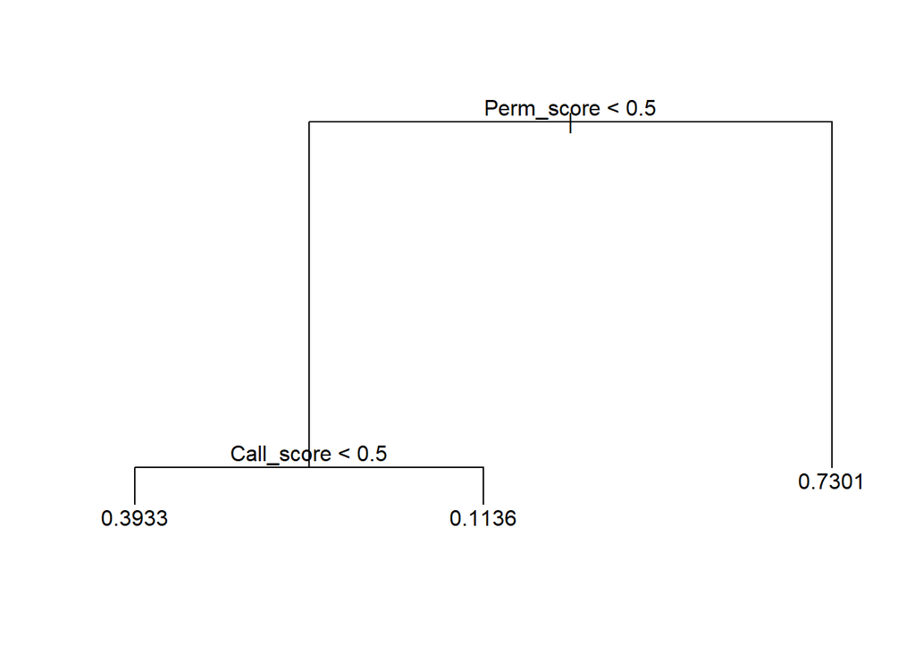

```r
plot(tree.intatt)
text(tree.intatt, pretty=0)
```

```r
tree.intatt
```

```
## node), split, n, deviance, yval
##       * denotes terminal node
##
## 1) root 900 209.000 0.6333
##   2) Perm_score < 0.5 222  49.660 0.3378
##     4) Call_score < 0.5 178  42.470 0.3933 *
##     5) Call_score > 0.5 44   4.432 0.1136 *
##   3) Perm_score > 0.5 678 133.600 0.7301 *
```

Cross Validation

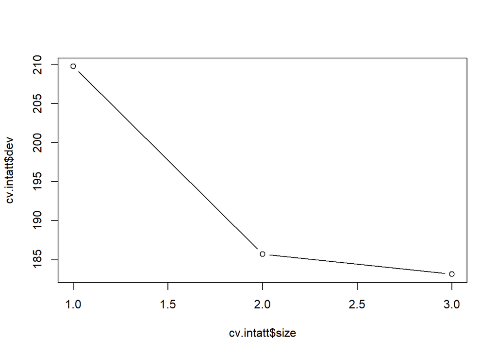

```r
cv.intatt = cv.tree(tree.intatt)
plot(cv.intatt$size ,cv.intatt$dev, type='b')
```

Pruning

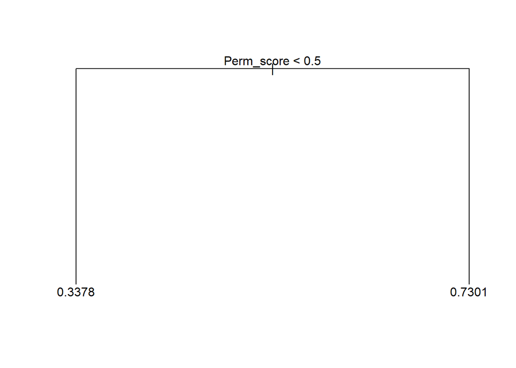

```r
prune.intatt = prune.tree(tree.intatt, best = 2)
plot(prune.intatt )
text(prune.intatt, pretty= 0)
```

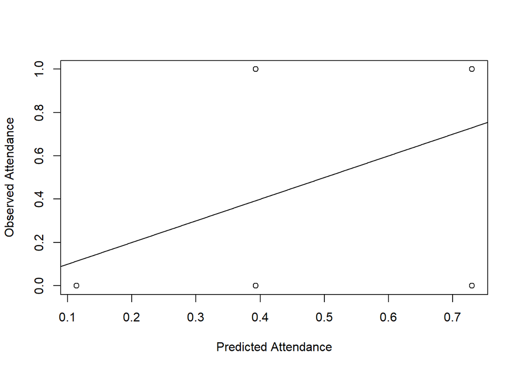

```r
tree.pred = predict(tree.intatt, newdata=int_df[-train, ])
plot(tree.pred, Obs_Att_class[-train], xlab = "Predicted Attendance", ylab = "Observed Attendance")
abline(0,1)
```

```r
mean((tree.pred - Obs_Att_class[-train])^2)
```

```
## [1] 0.2114168
```